# Notebook

Here, you will learn how to structure, featurize, and make a large imaging collection queryable for large-scale machine learning:

[output not shown]

First, we will load and annotate a collection of microscopy images in TIFF format that [was previously uploaded](https://lamin.ai/scportrait/examples/transform/asoq6WyPequ8?).

The images used here were acquired as part of a [study](https://www.google.com/url?sa=t&source=web&rct=j&opi=89978449&url=https://www.biorxiv.org/content/10.1101/2023.06.01.542416v1&ved=2ahUKEwj3m56hs52LAxWxRfEDHQZwKZ8QFnoECBIQAQ&usg=AOvVaw04HsGDIPcIPr1ldblXuh0Z) on autophagy, a cellular process during which cells recycle their components in autophagosomes.

The study tracked genetic determinants of autophagy through fluorescence microscopy of human U2OS cells. Cells were engineered to express two markers: the fluorescent autophagosome marker `mCherry-LC3B` and the fluorescent plasma membrane label `LckLip-mNeon`. Autophagy was induced using `Torin-1`, and cells were counterstained for DNA visualization.

These three structures are visualized in three separate image channels:

| Channel | Imaged Structure |
| --- | --- |
| 1 | DNA |
| 2 | Autophagosomes |
| 3 | Plasma Membrane |

```python
# pip install 'lamindb[jupyter,bionty]'
!lamin init --storage ./test-imaging --schema bionty
```

```
→ initialized lamindb: zethson/test-imaging
```

```python
import lamindb as ln
import bionty as bt
from tifffile import imread
import matplotlib.pyplot as plt

ln.track()
```

```
→ connected lamindb: zethson/test-imaging
→ created Transform('3ayBoDKxhXPJ0000'), started new Run('DgTXPRRv...') at 2025-03-20 16:27:09 UTC
→ notebook imports: bionty==1.1.2 lamindb==1.3.0 matplotlib==3.10.1 tifffile==2025.3.13
```

All image metadata is stored in an already ingested `.csv` file on the `scportrait/examples` instance.

```python
metadata_files = ln.Artifact.using("scportrait/examples").get(
    key="input_data_imaging_usecase/metadata_files.csv"
).load()

metadata_files.head(2)
```

```
→ completing transfer to track Artifact('jdjwcUB0') as input
→ mapped records:
→ transferred records: Artifact(uid='jdjwcUB0w1QAHAYm0000'), Storage(uid='r7YUayXjktSb')
```

|  | image_path | genotype | stimulation | cell_line | cell_line_clone | channel | FOV | magnification | microscope | imaged structure | resolution |
| --- | --- | --- | --- | --- | --- | --- | --- | --- | --- | --- | --- |
| 0 | input_data_imaging_usecase/images/Timepoint001... | WT | 14h Torin-1 | U2OS | U2OS lcklip-mNeon mCherryLC3B clone 1 | Alexa488 | FOV1 | 20X | Opera Phenix | LckLip-mNeon | 0.597976 |
| 1 | input_data_imaging_usecase/images/Timepoint001... | WT | 14h Torin-1 | U2OS | U2OS lcklip-mNeon mCherryLC3B clone 1 | Alexa488 | FOV2 | 20X | Opera Phenix | LckLip-mNeon | 0.597976 |

```python
metadata_files.apply(lambda col: col.unique())
```

```
image_path          [input_data_imaging_usecase/images/Timepoint00...
genotype                                                 [WT, EI24KO]
stimulation                                  [14h Torin-1, untreated]
cell_line                                                      [U2OS]
cell_line_clone     [U2OS lcklip-mNeon mCherryLC3B clone 1, U2OS l...
channel                                     [Alexa488, DAPI, mCherry]
FOV                                                      [FOV1, FOV2]
magnification                                                   [20X]
microscope                                             [Opera Phenix]
imaged structure                    [LckLip-mNeon, DNA, mCherry-LC3B]
resolution                                              [0.597976081]
dtype: object
```

All images are of the same cell line (U2OS), which have been imaged on an Opera Phenix microscope at 20X magnification. To induce autophagy, the cells have either been treated with `Torin-1`, a small molecule that mimics starvation, for 14 hours, or left untreated as a control.

To visualize the process of autophagosome formation, the U2OS cells have been genetically engineered to express fluorescently tagged proteins. `LC3B` is a marker of autophagosomes, allowing us to visualize their formation in the mCherry channel. `LckLip` is a membrane-targeted fluorescent protein, which helps outline the cellular boundaries of individual cells in the `Alexa488` channel. Furthermore, the cells’ DNA was stained using `Hoechst`, which we can visualize in the `DAPI` channel to identify the nuclei of individual cells.

In addition to expressing fluorescently tagged proteins, some of the cells have had the `EI24` gene knocked out, leading to two different genotypes: `WT` (wild-type) cells and `EI24KO` (knockout) cells. For each genotype, two different clonal cell lines were analyzed, with multiple fields of view (FOVs) captured per condition.

To enable queries on our images, we annotate them with the corresponding metadata.

```python
autophagy_imaging_schema = ln.Schema(
    name="Autophagy imaging schema",
    features=[
        ln.Feature(name="genotype", dtype=ln.ULabel.name).save(),
        ln.Feature(name="stimulation", dtype=ln.ULabel.name).save(),
        ln.Feature(name="cell_line", dtype=bt.CellLine.name).save(),
        ln.Feature(name="cell_line_clone", dtype=ln.ULabel.name).save(),
        ln.Feature(name="channel", dtype=ln.ULabel.name).save(),
        ln.Feature(name="FOV", dtype=ln.ULabel.name).save(),
        ln.Feature(name="magnification", dtype=ln.ULabel.name).save(),
        ln.Feature(name="microscope", dtype=ln.ULabel.name).save(),
        ln.Feature(name="imaged structure", dtype=ln.ULabel.name).save(),
        ln.Feature(
            name="resolution", dtype=float, description="conversion factor for px to µm"
        ).save(),
    ],
    coerce_dtype=True,
).save()
```

```python
# convert to categorical instead of object

curator = ln.curators.DataFrameCurator(metadata_files, autophagy_imaging_schema)
try:
    curator.validate()
except ln.core.exceptions.ValidationError as e:
    print(e)
```

```
→ Created a ULabel type: ULabel(uid='jfgGwGvl', name='Genotype', is_type=True, space_id=1, created_by_id=1, run_id=1, created_at=2025-03-20 16:27:14 UTC)
→ Created a ULabel type: ULabel(uid='p6iWFiX5', name='Stimulation', is_type=True, space_id=1, created_by_id=1, run_id=1, created_at=2025-03-20 16:27:14 UTC)
• saving validated records of 'cell_line'
✓ added 1 record from public with CellLine.name for "cell_line": 'U-2 OS cell'
→ Created a ULabel type: ULabel(uid='XuaJ5ryg', name='CellLineClone', is_type=True, space_id=1, created_by_id=1, run_id=1, created_at=2025-03-20 16:27:16 UTC)
→ Created a ULabel type: ULabel(uid='AlMtZtGH', name='Channel', is_type=True, space_id=1, created_by_id=1, run_id=1, created_at=2025-03-20 16:27:16 UTC)
→ Created a ULabel type: ULabel(uid='DVup0VFf', name='Fov', is_type=True, space_id=1, created_by_id=1, run_id=1, created_at=2025-03-20 16:27:16 UTC)
→ Created a ULabel type: ULabel(uid='LKqxQIa2', name='Magnification', is_type=True, space_id=1, created_by_id=1, run_id=1, created_at=2025-03-20 16:27:16 UTC)
→ Created a ULabel type: ULabel(uid='gjVNJTsA', name='Microscope', is_type=True, space_id=1, created_by_id=1, run_id=1, created_at=2025-03-20 16:27:16 UTC)
→ Created a ULabel type: ULabel(uid='Xk6vpIQ4', name='Imaged structure', is_type=True, space_id=1, created_by_id=1, run_id=1, created_at=2025-03-20 16:27:16 UTC)
• mapping "genotype" on ULabel.name
!   2 terms are not validated: 'WT', 'EI24KO'
    → fix typos, remove non-existent values, or save terms via .add_new_from("genotype")
• mapping "stimulation" on ULabel.name
!   2 terms are not validated: '14h Torin-1', 'untreated'
    → fix typos, remove non-existent values, or save terms via .add_new_from("stimulation")
• mapping "cell_line" on CellLine.name
!   1 term is not validated: 'U2OS'
    1 synonym found: "U2OS" → "U-2 OS cell"
    → curate synonyms via .standardize("cell_line")
• mapping "cell_line_clone" on ULabel.name
!   4 terms are not validated: 'U2OS lcklip-mNeon mCherryLC3B clone 1', 'U2OS lcklip-mNeon mCherryLC3B clone 2', 'U2OS lcklip-mNeon mCherryLC3B EI24 KO clone 1', 'U2OS lcklip-mNeon mCherryLC3B EI24 KO clone 2'
    → fix typos, remove non-existent values, or save terms via .add_new_from("cell_line_clone")
• mapping "channel" on ULabel.name
!   3 terms are not validated: 'Alexa488', 'DAPI', 'mCherry'
    → fix typos, remove non-existent values, or save terms via .add_new_from("channel")
• mapping "FOV" on ULabel.name
!   2 terms are not validated: 'FOV1', 'FOV2'
    → fix typos, remove non-existent values, or save terms via .add_new_from("FOV")
• mapping "magnification" on ULabel.name
!   1 term is not validated: '20X'
    → fix typos, remove non-existent values, or save terms via .add_new_from("magnification")
• mapping "microscope" on ULabel.name
!   1 term is not validated: 'Opera Phenix'
    → fix typos, remove non-existent values, or save terms via .add_new_from("microscope")
• mapping "imaged structure" on ULabel.name
!   3 terms are not validated: 'LckLip-mNeon', 'DNA', 'mCherry-LC3B'
    → fix typos, remove non-existent values, or save terms via .add_new_from("imaged structure")
3 terms are not validated: 'LckLip-mNeon', 'DNA', 'mCherry-LC3B'
    → fix typos, remove non-existent values, or save terms via .add_new_from("imaged structure")
```

Add and standardize missing terms:

```python
curator.cat.standardize("cell_line")
curator.cat.add_new_from("all")
curator.validate()
```

```
✓ standardized 1 synonym in "cell_line": "U2OS" → "U-2 OS cell"
✓ added 2 records with ULabel.name for "genotype": 'WT', 'EI24KO'
✓ added 2 records with ULabel.name for "stimulation": '14h Torin-1', 'untreated'
✓ added 4 records with ULabel.name for "cell_line_clone": 'U2OS lcklip-mNeon mCherryLC3B EI24 KO clone 2', 'U2OS lcklip-mNeon mCherryLC3B EI24 KO clone 1', 'U2OS lcklip-mNeon mCherryLC3B clone 1', 'U2OS lcklip-mNeon mCherryLC3B clone 2'
! records with similar names exist! did you mean to load one of them?
```

| id | uid | name | is_type | description | reference | reference_type | space_id | type_id | run_id | created_at | created_by_id | _aux | _branch_code |
| --- | --- | --- | --- | --- | --- | --- | --- | --- | --- | --- | --- | --- | --- |
| 13 | z31Cu2PE | U2OS lcklip-mNeon mCherryLC3B EI24 KO clone 2 | False | None | None | None | 1 | None | 1 | 2025-03-20 16:27:16.373000+00:00 | 1 | None | 1 |
| 14 | yKUif1Fo | U2OS lcklip-mNeon mCherryLC3B EI24 KO clone 1 | False | None | None | None | 1 | None | 1 | 2025-03-20 16:27:16.373000+00:00 | 1 | None | 1 |
| 15 | ZmymZDsb | U2OS lcklip-mNeon mCherryLC3B clone 1 | False | None | None | None | 1 | None | 1 | 2025-03-20 16:27:16.373000+00:00 | 1 | None | 1 |

```
✓ added 3 records with ULabel.name for "channel": 'DAPI', 'mCherry', 'Alexa488'
✓ added 2 records with ULabel.name for "FOV": 'FOV1', 'FOV2'
✓ added 1 record with ULabel.name for "magnification": '20X'
✓ added 1 record with ULabel.name for "microscope": 'Opera Phenix'
! records with similar names exist! did you mean to load one of them?
```

| id | uid | name | is_type | description | reference | reference_type | space_id | type_id | run_id | created_at | created_by_id | _aux | _branch_code |
| --- | --- | --- | --- | --- | --- | --- | --- | --- | --- | --- | --- | --- | --- |
| 13 | z31Cu2PE | U2OS lcklip-mNeon mCherryLC3B EI24 KO clone 2 | False | None | None | None | 1 | None | 1 | 2025-03-20 16:27:16.373000+00:00 | 1 | None | 1 |
| 14 | yKUif1Fo | U2OS lcklip-mNeon mCherryLC3B EI24 KO clone 1 | False | None | None | None | 1 | None | 1 | 2025-03-20 16:27:16.373000+00:00 | 1 | None | 1 |
| 15 | ZmymZDsb | U2OS lcklip-mNeon mCherryLC3B clone 1 | False | None | None | None | 1 | None | 1 | 2025-03-20 16:27:16.373000+00:00 | 1 | None | 1 |

```
✓ added 3 records with ULabel.name for "imaged structure": 'mCherry-LC3B', 'DNA', 'LckLip-mNeon'
✓ "genotype" is validated against ULabel.name
✓ "stimulation" is validated against ULabel.name
✓ "cell_line" is validated against CellLine.name
✓ "cell_line_clone" is validated against ULabel.name
✓ "channel" is validated against ULabel.name
✓ "FOV" is validated against ULabel.name
✓ "magnification" is validated against ULabel.name
✓ "microscope" is validated against ULabel.name
✓ "imaged structure" is validated against ULabel.name
```

Now lets add all of our images to our lamindb instance in a loop already annotating all relevant metadata.

```python
# Create study feature and associated label
ln.Feature(name="study", dtype=ln.ULabel).save()
ln.ULabel(name="autophagy imaging").save()

# loop through all artifacts and add feature values
artifacts = []
for idx, row in metadata_files.iterrows():
    artifact = ln.Artifact(
        row["image_path"],
        description="raw image of U2OS cells stained for autophagy markers",
    )
    artifact.save()
    artifact.cell_lines.add(bt.CellLine.filter(name=row.cell_line).one())

    artifact.features.add_values(
        {
            "genotype": row.genotype,
            "stimulation": row.stimulation,
            "cell_line_clone": row.cell_line_clone,
            "channel": row.channel,
            "imaged structure": row["imaged structure"],
            "study": "autophagy imaging",
            "FOV": row.FOV,
            "magnification": row.magnification,
            "microscope": row.microscope,
            "resolution": row.resolution,
        }
    )

    artifacts.append(artifact)
```

[output not shown]

[output cut: 41 more lines]

[output not shown]

```python
artifacts[0].describe()
```

```
Artifact .tif
├── General
│   ├── .uid = 'WI3WsBdcKSN0HNQc0000'
│   ├── .size = 2333056
│   ├── .hash = '0aoXxT857VvKAGo9UQo-8g'
│   ├── .path = /home/lukas/code/lamin-usecases/docs/test-imaging/.lamindb/WI3WsBdcKSN0HNQc0000.tif
│   ├── .created_by = zethson (Lukas Heumos)
│   ├── .created_at = 2025-03-20 17:27:17
│   └── .transform = 'Imaging'
├── Linked features
│   └── FOV                         cat[ULabel.name]           FOV1
│       cell_line_clone             cat[ULabel.name]           U2OS lcklip-mNeon mCherryLC3B clone 1
│       channel                     cat[ULabel.name]           Alexa488
│       genotype                    cat[ULabel.name]           WT
│       imaged structure            cat[ULabel.name]           LckLip-mNeon
│       magnification               cat[ULabel.name]           20X
│       microscope                  cat[ULabel.name]           Opera Phenix
│       stimulation                 cat[ULabel.name]           14h Torin-1
│       study                       cat[ULabel]                autophagy imaging
│       resolution                  float                      0.597976081
└── Labels
    └── .cell_lines                 bionty.CellLine            U-2 OS cell
        .ulabels                    ULabel                     WT, 14h Torin-1, U2OS lcklip-mNeon mCher…
```

In addition, we create a collection to hold all `Artifacts` that belong to this specific imaging study.

```python
collection = ln.Collection(
    artifacts,
    key="Annotated autophagy imaging raw images",
    description="annotated microscopy images of cells stained for autophagy markers",
)
collection.save()
```

```
Collection(uid='8JDTDQzMBLVRgp4Y0000', is_latest=True, key='Annotated autophagy imaging raw images', description='annotated microscopy images of cells stained for autophagy markers', hash='6L85RD5Q83sQ7ZwaNOIMNw', space_id=1, created_by_id=1, run_id=1, created_at=2025-03-20 16:27:21 UTC)
```

Let's look at some example images where we match images from the same clone, stimulation condition, and FOV to ensure correct channel alignment.

[output not shown]

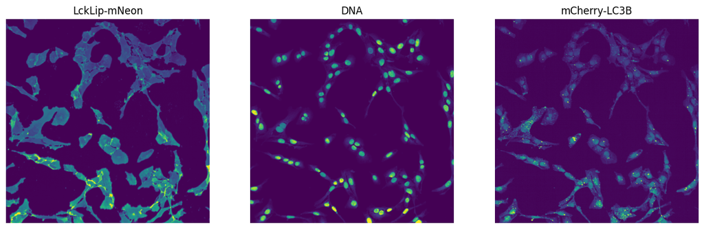

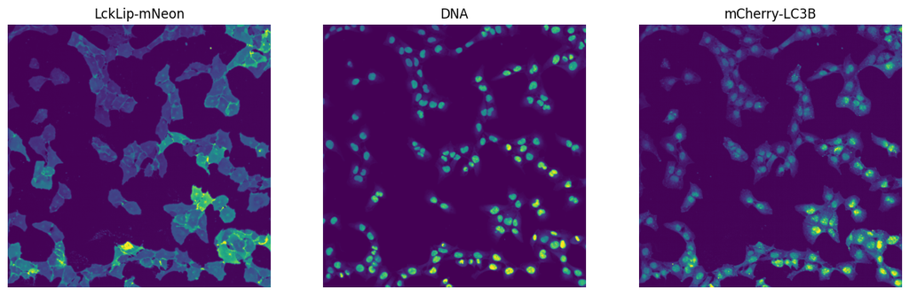

```python
FOV_example_images = (
    metadata_files.sort_values(by=["cell_line_clone", "stimulation", "FOV"])
    .head(3)
    .reset_index(drop=True)
)

fig, axs = plt.subplots(1, 3, figsize=(15, 5))
for idx, row in FOV_example_images.iterrows():
    path = ln.Artifact.using("scportrait/examples").get(key=row["image_path"]).cache()
    image = imread(path)
    axs[idx].imshow(image)
    axs[idx].set_title(f"{row['imaged structure']}")
    axs[idx].axis("off")

FOV_example_images = (
    metadata_files.sort_values(by=["cell_line_clone", "stimulation", "FOV"])
    .tail(3)
    .reset_index(drop=True)
)

fig, axs = plt.subplots(1, 3, figsize=(15, 5))
for idx, row in FOV_example_images.iterrows():
    path = ln.Artifact.using("scportrait/examples").get(key=row["image_path"]).cache()
    image = imread(path)
    axs[idx].imshow(image)
    axs[idx].set_title(f"{row['imaged structure']}")
    axs[idx].axis("off")
```

```python
ln.finish()
```